# Reproducible Research: Peer Assessment 1

Setting Global Options

```r
knitr::opts_chunk$set(echo = TRUE,
                      warning = FALSE,
                      message = FALSE)
```

## Loading and preprocessing the data

Importing tidyverse, dataset and converting date.

```r
library(tidyverse)
df <- read.csv("activity.csv")
df$date <- as.Date(df$date)
```

## What is mean total number of steps taken per day?

Aggregating data to daily frequency and printing summary.

```r
df_daily <- df %>%
    filter(!is.na(steps)) %>%
    group_by(date) %>%
    summarise(total_steps = sum(steps, na.rm = TRUE))

df_daily_summary <- df_daily %>%
    summarise(mean_total = mean(total_steps, na.rm = TRUE),
              median_total = median(total_steps, na.rm = TRUE))

print(paste("mean total number of steps taken per day:", round(df_daily_summary[[1]], 0)))
```

```
## [1] "mean total number of steps taken per day: 10766"
```

```r
print(paste("median total number of steps taken per day:", round(df_daily_summary[[2]], 0)))
```

```
## [1] "median total number of steps taken per day: 10765"
```

Histogram of Daily Steps

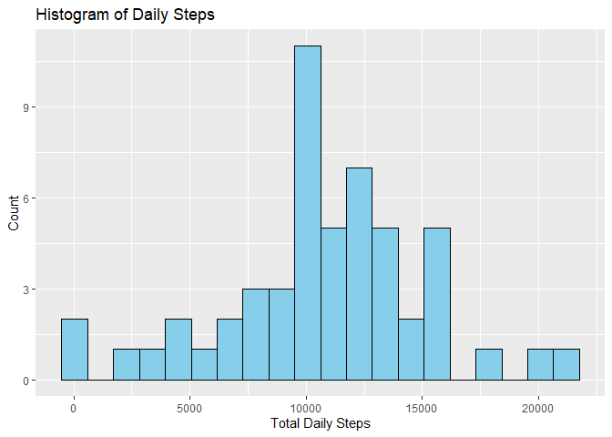

```r
g <- ggplot(df_daily, aes(x = total_steps)) +
    geom_histogram(bins = 20, fill = "skyblue", color = "black") +
    labs(title = "Histogram of Daily Steps",
         x = "Total Daily Steps",
         y = "Count")
print(g)
```

## What is the average daily activity pattern?

Average Daily Activity Pattern time series plot.

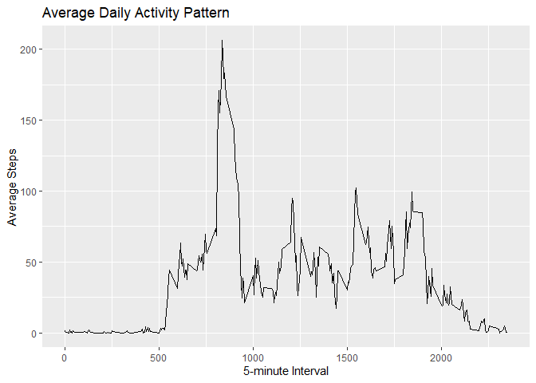

```r
df_interval <- df %>%
    group_by(interval) %>%
    summarise(avg_steps = mean(steps, na.rm = TRUE)) %>%
    arrange(interval)

g2 <- ggplot(df_interval, aes(x = interval, y = avg_steps)) +
    geom_line() +
    labs(
        title = "Average Daily Activity Pattern",
        x = "5-minute Interval",
        y = "Average Steps")

print(g2)
```

5-minute interval, on average across all the days in the dataset, that contains the maximum number of steps.

```r
interval_max <- df_interval %>%
    slice_max(avg_steps, n = 1) %>%
    pull(interval)
print(paste("interval which has max average steps:", interval_max))
```

```
## [1] "interval which has max average steps: 835"
```

## Imputing missing values

#### Strategy for imputing NAs

- I’m going to impute NAs by using the 5-min interval averages derived above. The 5-min interval will help retain the shape of the activities throughout the day.
- The process will use the 5-min interval averages if NA is present, otherwise the original steps will be used in a newly derived column called steps_filled.

```r
missing_values <- df %>%
    filter(is.na(steps)) %>%
    nrow()

print(paste("number of missing values:", missing_values))
```

```
## [1] "number of missing values: 2304"
```

```r
df_imputed <- df %>%
    left_join(df_interval, by = "interval") %>%
    mutate(steps_filled = if_else(is.na(steps), avg_steps, steps))

df_daily_imputed <- df_imputed %>%
    group_by(date) %>%
    summarise(total_steps = sum(steps_filled, na.rm = TRUE))
```

Histogram after imputation. Compared to the original histogram without imputation of NAs, the histogram below shows more counts in the mean/median step range. This is as expected as the NAs were imputed using the 5-min interval averages.

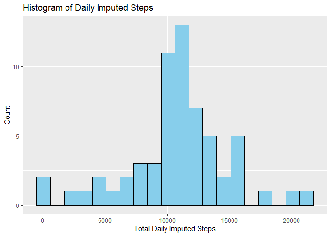

```r
g3 <- ggplot(df_daily_imputed, aes(x = total_steps)) +
    geom_histogram(bins = 20, fill = "skyblue", color = "black") +
    labs(title = "Histogram of Daily Imputed Steps",
         x = "Total Daily Imputed Steps",
         y = "Count")
print(g3)
```

Summary of mean and median after imputation.

```r
df_daily_imputed_summary <- df_daily_imputed %>%
    summarise(mean_total = mean(total_steps, na.rm = TRUE),
              median_total = median(total_steps, na.rm = TRUE))

print(paste("Summary of mean imputation:", round(df_daily_imputed_summary[[1]], 0)))
```

```
## [1] "Summary of mean imputation: 10766"
```

```r
print(paste("Summary of median imputation:", round(df_daily_imputed_summary[[2]], 0)))
```

```
## [1] "Summary of median imputation: 10766"
```

## Are there differences in activity patterns between weekdays and weekends?

Yes, there are noticeable differences in activity patterns:

- **Weekends show higher overall activity during the daytime**, particularly between **10 AM and 5 PM**.
- **Weekdays have a higher peak 5-minute interval**, with a maximum of about **230 steps at interval 835**, compared to about **167 steps at interval 915** on weekends.

```r
df_imputed <- df_imputed %>%
    mutate(
        day_type = if_else(
            wday(date, label = TRUE) %in% c("Sat", "Sun"),
            "weekend",
            "weekday"),
        day_type = factor(day_type, levels = c("weekend", "weekday")))
```

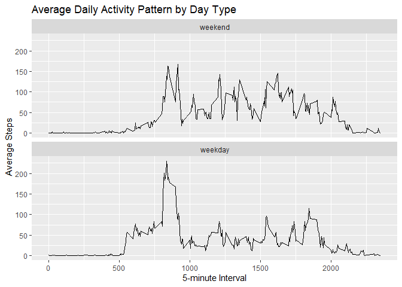

```r
df_imputed_day_type <- df_imputed %>%
    group_by(interval, day_type) %>%
    summarise(avg_steps = mean(steps_filled, na.rm = TRUE)) %>%
    arrange(interval, day_type)

g4 <- ggplot(df_imputed_day_type, aes(x = interval, y = avg_steps)) +
    geom_line() +
    facet_wrap(~ day_type, ncol = 1) +
    labs(
        title = "Average Daily Activity Pattern by Day Type",
        x = "5-minute Interval",
        y = "Average Steps"
    )

print(g4)
```